# Project: Wrangling and Analyze Data

- 1. Data Gathering
- 2. Assessing Data
  - 1.1 Quality issues
  - 1.2 Tidiness issues
- 3. Cleaning Data
  - 3.1 Cleaning(Quality isues)
  - 3.2 Cleaning(Tidiness isues)
- 4. Storing Data
- 5. Analyzing and Visualizing Data
  - 5.1 Insights
- 6. Conclusion
- 7. Limitation
- 8. References

## Data Gathering

In the cells below, we gather the three necessary pieces of data for this project and load them in the notebook.

1. Directly download the WeRateDogs Twitter archive data (twitter_archive_enhanced.csv)

```python
# importing statements for the needed packages

import pandas as pd
import numpy as np
import requests
import os
import json
%matplotlib inline
import matplotlib.pyplot as plt
import matplotlib.patches as mpatches
import seaborn as sns
```

```python
#Loading the Twitter Archive data

archive_df = pd.read_csv('twitter_archive_enhanced.csv')
archive_df[:10]
```

|  | tweet_id | in_reply_to_status_id | in_reply_to_user_id | timestamp | source | text | retweeted_status_id | retweeted_status_user_id | retweeted_status_timestamp | expanded_urls | rating_numerator | rating_denominator | name | doggo | floofer | pupper | puppo |
| --- | --- | --- | --- | --- | --- | --- | --- | --- | --- | --- | --- | --- | --- | --- | --- | --- | --- |
| 0 | 892420643555336193 | NaN | NaN | 2017-08-01 16:23:56 +0000 | <a href="http://twitter.com/download/iphone" r... | This is Phineas. He's a mystical boy. Only eve... | NaN | NaN | NaN | https://twitter.com/dog_rates/status/892420643... | 13 | 10 | Phineas | None | None | None | None |
| 1 | 892177421306343426 | NaN | NaN | 2017-08-01 00:17:27 +0000 | <a href="http://twitter.com/download/iphone" r... | This is Tilly. She's just checking pup on you.... | NaN | NaN | NaN | https://twitter.com/dog_rates/status/892177421... | 13 | 10 | Tilly | None | None | None | None |
| 2 | 891815181378084864 | NaN | NaN | 2017-07-31 00:18:03 +0000 | <a href="http://twitter.com/download/iphone" r... | This is Archie. He is a rare Norwegian Pouncin... | NaN | NaN | NaN | https://twitter.com/dog_rates/status/891815181... | 12 | 10 | Archie | None | None | None | None |
| 3 | 891689557279858688 | NaN | NaN | 2017-07-30 15:58:51 +0000 | <a href="http://twitter.com/download/iphone" r... | This is Darla. She commenced a snooze mid meal... | NaN | NaN | NaN | https://twitter.com/dog_rates/status/891689557... | 13 | 10 | Darla | None | None | None | None |
| 4 | 891327558926688256 | NaN | NaN | 2017-07-29 16:00:24 +0000 | <a href="http://twitter.com/download/iphone" r... | This is Franklin. He would like you to stop ca... | NaN | NaN | NaN | https://twitter.com/dog_rates/status/891327558... | 12 | 10 | Franklin | None | None | None | None |
| 5 | 891087950875897856 | NaN | NaN | 2017-07-29 00:08:17 +0000 | <a href="http://twitter.com/download/iphone" r... | Here we have a majestic great white breaching ... | NaN | NaN | NaN | https://twitter.com/dog_rates/status/891087950... | 13 | 10 | None | None | None | None | None |
| 6 | 890971913173991426 | NaN | NaN | 2017-07-28 16:27:12 +0000 | <a href="http://twitter.com/download/iphone" r... | Meet Jax. He enjoys ice cream so much he gets ... | NaN | NaN | NaN | https://gofundme.com/ydvmve-surgery-for-jax,ht... | 13 | 10 | Jax | None | None | None | None |
| 7 | 890729181411237888 | NaN | NaN | 2017-07-28 00:22:40 +0000 | <a href="http://twitter.com/download/iphone" r... | When you watch your owner call another dog a g... | NaN | NaN | NaN | https://twitter.com/dog_rates/status/890729181... | 13 | 10 | None | None | None | None | None |
| 8 | 890609185150312448 | NaN | NaN | 2017-07-27 16:25:51 +0000 | <a href="http://twitter.com/download/iphone" r... | This is Zoey. She doesn't want to be one of th... | NaN | NaN | NaN | https://twitter.com/dog_rates/status/890609185... | 13 | 10 | Zoey | None | None | None | None |
| 9 | 890240255349198849 | NaN | NaN | 2017-07-26 15:59:51 +0000 | <a href="http://twitter.com/download/iphone" r... | This is Cassie. She is a college pup. Studying... | NaN | NaN | NaN | https://twitter.com/dog_rates/status/890240255... | 14 | 10 | Cassie | doggo | None | None | None |

1. Use the Requests library to download the tweet image prediction (image_predictions.tsv)

```python
#Create request
url ='https://d17h27t6h515a5.cloudfront.net/topher/2017/August/599fd2ad_image-predictions/image-predictions.tsv'
response = requests.get(url)
```

```python
#Loading the image predictions file

img_pred = pd.read_csv('image_predictions.tsv', sep='\t')
img_pred[:10]
```

|  | tweet_id | jpg_url | img_num | p1 | p1_conf | p1_dog | p2 | p2_conf | p2_dog | p3 | p3_conf | p3_dog |
| --- | --- | --- | --- | --- | --- | --- | --- | --- | --- | --- | --- | --- |
| 0 | 666020888022790149 | https://pbs.twimg.com/media/CT4udn0WwAA0aMy.jpg | 1 | Welsh_springer_spaniel | 0.465074 | True | collie | 0.156665 | True | Shetland_sheepdog | 0.061428 | True |
| 1 | 666029285002620928 | https://pbs.twimg.com/media/CT42GRgUYAA5iDo.jpg | 1 | redbone | 0.506826 | True | miniature_pinscher | 0.074192 | True | Rhodesian_ridgeback | 0.072010 | True |
| 2 | 666033412701032449 | https://pbs.twimg.com/media/CT4521TWwAEvMyu.jpg | 1 | German_shepherd | 0.596461 | True | malinois | 0.138584 | True | bloodhound | 0.116197 | True |
| 3 | 666044226329800704 | https://pbs.twimg.com/media/CT5Dr8HUEAA-lEu.jpg | 1 | Rhodesian_ridgeback | 0.408143 | True | redbone | 0.360687 | True | miniature_pinscher | 0.222752 | True |
| 4 | 666049248165822465 | https://pbs.twimg.com/media/CT5IQmsXIAAKY4A.jpg | 1 | miniature_pinscher | 0.560311 | True | Rottweiler | 0.243682 | True | Doberman | 0.154629 | True |
| 5 | 666050758794694657 | https://pbs.twimg.com/media/CT5Jof1WUAEuVxN.jpg | 1 | Bernese_mountain_dog | 0.651137 | True | English_springer | 0.263788 | True | Greater_Swiss_Mountain_dog | 0.016199 | True |
| 6 | 666051853826850816 | https://pbs.twimg.com/media/CT5KoJ1WoAAJash.jpg | 1 | box_turtle | 0.933012 | False | mud_turtle | 0.045885 | False | terrapin | 0.017885 | False |
| 7 | 666055525042405380 | https://pbs.twimg.com/media/CT5N9tpXIAAifs1.jpg | 1 | chow | 0.692517 | True | Tibetan_mastiff | 0.058279 | True | fur_coat | 0.054449 | False |
| 8 | 666057090499244032 | https://pbs.twimg.com/media/CT5PY90WoAAQGLo.jpg | 1 | shopping_cart | 0.962465 | False | shopping_basket | 0.014594 | False | golden_retriever | 0.007959 | True |
| 9 | 666058600524156928 | https://pbs.twimg.com/media/CT5Qw94XAAA_2dP.jpg | 1 | miniature_poodle | 0.201493 | True | komondor | 0.192305 | True | soft-coated_wheaten_terrier | 0.082086 | True |

1. Use the Tweepy library to query additional data via the Twitter API (tweet_json.txt)

```python
tweets_list = []
with open('tweet-json.txt', 'r') as file:
    for line in file:
        data = json.loads(line)
        tweets_list.append(data)

tweets_df = pd.DataFrame(tweets_list, columns = ['id', 'retweet_count', 'favorite_count'])

tweets_df[:20]
```

|  | id | retweet_count | favorite_count |
| --- | --- | --- | --- |
| 0 | 892420643555336193 | 8853 | 39467 |
| 1 | 892177421306343426 | 6514 | 33819 |
| 2 | 891815181378084864 | 4328 | 25461 |
| 3 | 891689557279858688 | 8964 | 42908 |
| 4 | 891327558926688256 | 9774 | 41048 |
| 5 | 891087950875897856 | 3261 | 20562 |
| 6 | 890971913173991426 | 2158 | 12041 |
| 7 | 890729181411237888 | 16716 | 56848 |
| 8 | 890609185150312448 | 4429 | 28226 |
| 9 | 890240255349198849 | 7711 | 32467 |
| 10 | 890006608113172480 | 7624 | 31166 |
| 11 | 889880896479866881 | 5156 | 28268 |
| 12 | 889665388333682689 | 8538 | 38818 |
| 13 | 889638837579907072 | 4735 | 27672 |
| 14 | 889531135344209921 | 2321 | 15359 |
| 15 | 889278841981685760 | 5637 | 25652 |
| 16 | 888917238123831296 | 4709 | 29611 |
| 17 | 888804989199671297 | 4559 | 26080 |
| 18 | 888554962724278272 | 3732 | 20290 |
| 19 | 888078434458587136 | 3653 | 22201 |

## Assessing Data

In this section, we detect and document quality issues and tidiness issues using both visual assessment and programmatic assessement to assess the data.

```python
#Check information about the dataframe
archive_df.info()
```

```
<class 'pandas.core.frame.DataFrame'>
RangeIndex: 2356 entries, 0 to 2355
Data columns (total 17 columns):
tweet_id                      2356 non-null int64
in_reply_to_status_id         78 non-null float64
in_reply_to_user_id           78 non-null float64
timestamp                     2356 non-null object
source                        2356 non-null object
text                          2356 non-null object
retweeted_status_id           181 non-null float64
retweeted_status_user_id      181 non-null float64
retweeted_status_timestamp    181 non-null object
expanded_urls                 2297 non-null object
rating_numerator              2356 non-null int64
rating_denominator            2356 non-null int64
name                          2356 non-null object
doggo                         2356 non-null object
floofer                       2356 non-null object
pupper                        2356 non-null object
puppo                         2356 non-null object
dtypes: float64(4), int64(3), object(10)
memory usage: 313.0+ KB
```

```python
#Check for duplicate

sum(archive_df.duplicated())
```

```
0
```

```python
archive_df.nunique()
```

```
tweet_id                      2356
in_reply_to_status_id           77
in_reply_to_user_id             31
timestamp                     2356
source                           4
text                          2356
retweeted_status_id            181
retweeted_status_user_id        25
retweeted_status_timestamp     181
expanded_urls                 2218
rating_numerator                40
rating_denominator              18
name                           957
doggo                            2
floofer                          2
pupper                           2
puppo                            2
dtype: int64
```

```python
archive_df.sample(2)
```

|  | tweet_id | in_reply_to_status_id | in_reply_to_user_id | timestamp | source | text | retweeted_status_id | retweeted_status_user_id | retweeted_status_timestamp | expanded_urls | rating_numerator | rating_denominator | name | doggo | floofer | pupper | puppo |
| --- | --- | --- | --- | --- | --- | --- | --- | --- | --- | --- | --- | --- | --- | --- | --- | --- | --- |
| 101 | 872668790621863937 | NaN | NaN | 2017-06-08 04:17:07 +0000 | <a href="http://twitter.com/download/iphone" r... | RT @loganamnosis: Penelope here is doing me qu... | 8.726576e+17 | 154767397.0 | 2017-06-08 03:32:35 +0000 | https://twitter.com/loganamnosis/status/872657... | 14 | 10 | None | None | None | None | None |
| 1360 | 703268521220972544 | NaN | NaN | 2016-02-26 17:20:56 +0000 | <a href="http://twitter.com/download/iphone" r... | Happy Friday here's a sleepy pupper 12/10 http... | NaN | NaN | NaN | https://twitter.com/dog_rates/status/703268521... | 12 | 10 | None | None | None | pupper | None |

```python
img_pred.info()
```

```
<class 'pandas.core.frame.DataFrame'>
RangeIndex: 2075 entries, 0 to 2074
Data columns (total 12 columns):
tweet_id    2075 non-null int64
jpg_url     2075 non-null object
img_num     2075 non-null int64
p1          2075 non-null object
p1_conf     2075 non-null float64
p1_dog      2075 non-null bool
p2          2075 non-null object
p2_conf     2075 non-null float64
p2_dog      2075 non-null bool
p3          2075 non-null object
p3_conf     2075 non-null float64
p3_dog      2075 non-null bool
dtypes: bool(3), float64(3), int64(2), object(4)
memory usage: 152.1+ KB
```

```python
sum(img_pred.duplicated())
```

```
0
```

```python
img_pred.nunique()
```

```
tweet_id    2075
jpg_url     2009
img_num        4
p1           378
p1_conf     2006
p1_dog         2
p2           405
p2_conf     2004
p2_dog         2
p3           408
p3_conf     2006
p3_dog         2
dtype: int64
```

```python
img_pred.sample(3)
```

|  | tweet_id | jpg_url | img_num | p1 | p1_conf | p1_dog | p2 | p2_conf | p2_dog | p3 | p3_conf | p3_dog |
| --- | --- | --- | --- | --- | --- | --- | --- | --- | --- | --- | --- | --- |
| 1473 | 780192070812196864 | https://pbs.twimg.com/media/CtPMhwvXYAIt6NG.jpg | 1 | vizsla | 0.144012 | True | mongoose | 0.091474 | False | hatchet | 0.073545 | False |
| 17 | 666104133288665088 | https://pbs.twimg.com/media/CT56LSZWoAAlJj2.jpg | 1 | hen | 0.965932 | False | cock | 0.033919 | False | partridge | 0.000052 | False |
| 1658 | 810984652412424192 | https://pbs.twimg.com/media/C0EyPZbXAAAceSc.jpg | 1 | golden_retriever | 0.871342 | True | Tibetan_mastiff | 0.036708 | True | Labrador_retriever | 0.025823 | True |

```python
tweets_df.info()
```

```
<class 'pandas.core.frame.DataFrame'>
RangeIndex: 2354 entries, 0 to 2353
Data columns (total 3 columns):
id                2354 non-null int64
retweet_count     2354 non-null int64
favorite_count    2354 non-null int64
dtypes: int64(3)
memory usage: 55.2 KB
```

```python
sum(tweets_df.duplicated())
```

```
0
```

```python
tweets_df.sample(5)
```

|  | id | retweet_count | favorite_count |
| --- | --- | --- | --- |
| 936 | 753294487569522689 | 1191 | 3758 |
| 657 | 791672322847637504 | 3661 | 13129 |
| 1381 | 700847567345688576 | 558 | 2637 |
| 444 | 819227688460238848 | 7733 | 25652 |
| 1683 | 681654059175129088 | 1045 | 2903 |

```python
# To find duplicate column names in the three tables
all_columns = pd.Series(list(archive_df) + list(img_pred) + list(tweets_df))
all_columns[all_columns.duplicated()]
```

```
17    tweet_id
dtype: object
```

### Quality issues

1. twitter archive table - Remove retweets in the 'text' column i.e. text starting with RT @
2. twitter archive table - unnecessary in_reply_to_status_id column and in_reply_to_user_id column
1. twitter archive table - unnecessary retweeted_status_id column, retweeted_status_user_id column and retweeted_status_timestamp column as consideration is on original ratings
2. twitter archive table - Some dogs have non-dog names, for example: 'a' or 'an', 'such', 'the', 'getting', 'just' etc in the name column
3. twitter archive table - rating_numerator more than 10
4. twitter archive table - timestamp is an object rather than a timestamp
5. image prediction table - p1,p2 and p3 dog breed's names have no standard capital letter or lowercase names
6. image prediction table - Not all ratings are dog ratings
7. All tables - Presence of missing data in some tables which leads to differeing number of rows in the different tables. In twitter archive(2356), image prediction(2075) and tweets(2354)

### Tidiness issues

1. twitter archive table - The columns (doggo, floofer, pupper and puppo) are categorical variables yet placed in separate columns hence should be in a single column
2. tweets table - column named 'id' rather than 'tweet_id' to make it standard as with the other tables
3. All tables - Merging of the 3 dataframes to have one master table

## Cleaning Data

We make a copy of the original data before cleaning.

```python
# Make copies of original pieces of data
archive_df_clean = archive_df.copy()
img_pred_clean = img_pred.copy()
tweets_df_clean = tweets_df.copy()
```

### Cleaning (Quality Issues)

### Issue #1: Remove retweets in the 'text' column i.e. text starting with RT @

#### Define: Remove retweets by selecting rows that have null values in the retweet related columns then using pandas isnull() function

#### Code

```python
archive_df_clean = archive_df_clean[archive_df_clean.retweeted_status_id.isnull()]
archive_df_clean = archive_df_clean[archive_df_clean.retweeted_status_user_id.isnull()]
archive_df_clean = archive_df_clean[archive_df_clean.retweeted_status_timestamp.isnull()]
```

#### Test

```python
archive_df_clean.info()
```

```
<class 'pandas.core.frame.DataFrame'>
Int64Index: 2175 entries, 0 to 2355
Data columns (total 17 columns):
tweet_id                      2175 non-null int64
in_reply_to_status_id         78 non-null float64
in_reply_to_user_id           78 non-null float64
timestamp                     2175 non-null object
source                        2175 non-null object
text                          2175 non-null object
retweeted_status_id           0 non-null float64
retweeted_status_user_id      0 non-null float64
retweeted_status_timestamp    0 non-null object
expanded_urls                 2117 non-null object
rating_numerator              2175 non-null int64
rating_denominator            2175 non-null int64
name                          2175 non-null object
doggo                         2175 non-null object
floofer                       2175 non-null object
pupper                        2175 non-null object
puppo                         2175 non-null object
dtypes: float64(4), int64(3), object(10)
memory usage: 305.9+ KB
```

### Issue #2 and #3: twitter archive: unnecessary in_reply_to_status_id column, in_reply_to_user_id column, unnecessary retweeted_status_id column, retweeted_status_user_id column, retweeted_status_timestamp column as consideration is on original ratings

#### Define: Drop the in_reply and retweeted_status columns to remain with original ratings only

#### Code

```python
archive_df_clean.drop(['in_reply_to_status_id', 'in_reply_to_user_id','retweeted_status_id', 'retweeted_status_user_id', 'retweeted_status_timestamp'], axis=1, inplace=True)
```

#### Test

```python
archive_df_clean.columns
```

```
Index(['tweet_id', 'timestamp', 'source', 'text', 'expanded_urls',
       'rating_numerator', 'rating_denominator', 'name', 'doggo', 'floofer',
       'pupper', 'puppo'],
      dtype='object')
```

### Issue #4: twitter archive: Some dogs have non-dog names, for example: 'a' or 'an', 'such', 'the', 'getting', 'just' etc in the name column

#### Define: Replace the non-dog names with np.nan to make it standard if a valid name is not given

#### Code

```python
mask = archive_df_clean['name'].str.islower()
column_name = 'name'
archive_df_clean.loc[mask, column_name] = np.nan
```

#### Test

```python
archive_df_clean.name.head(10)
```

```
0     Phineas
1       Tilly
2      Archie
3       Darla
4    Franklin
5        None
6         Jax
7        None
8        Zoey
9      Cassie
Name: name, dtype: object
```

```python
archive_df_clean.name.tail(10)
```

```
2346     NaN
2347     NaN
2348     NaN
2349     NaN
2350     NaN
2351    None
2352     NaN
2353     NaN
2354     NaN
2355    None
Name: name, dtype: object
```

### Issue #6: twitter archive: timestamp is an object rather than a timestamp

#### Define: Convert the timestamp column from a string to datetime

#### Code

```python
import datetime
archive_df_clean['timestamp']= pd.to_datetime(archive_df_clean['timestamp'])
```

#### Test

```python
archive_df_clean.info()
```

```
<class 'pandas.core.frame.DataFrame'>
Int64Index: 2175 entries, 0 to 2355
Data columns (total 12 columns):
tweet_id              2175 non-null int64
timestamp             2175 non-null datetime64[ns]
source                2175 non-null object
text                  2175 non-null object
expanded_urls         2117 non-null object
rating_numerator      2175 non-null int64
rating_denominator    2175 non-null int64
name                  2071 non-null object
doggo                 2175 non-null object
floofer               2175 non-null object
pupper                2175 non-null object
puppo                 2175 non-null object
dtypes: datetime64[ns](1), int64(3), object(8)
memory usage: 220.9+ KB
```

### Issue #7: image prediction: p1,p2 and p3 dog breed's names have no standard capital letter or lowercase names

#### Define: Convert the names to lower case to make it standard

#### Code

```python
img_pred_clean['p1'] = img_pred_clean['p1'].str.lower()
img_pred_clean['p2'] = img_pred_clean['p2'].str.lower()
img_pred_clean['p3'] = img_pred_clean['p3'].str.lower()
```

#### Test

```python
img_pred_clean[:10]
```

|  | tweet_id | jpg_url | img_num | p1 | p1_conf | p1_dog | p2 | p2_conf | p2_dog | p3 | p3_conf | p3_dog |
| --- | --- | --- | --- | --- | --- | --- | --- | --- | --- | --- | --- | --- |
| 0 | 666020888022790149 | https://pbs.twimg.com/media/CT4udn0WwAA0aMy.jpg | 1 | welsh_springer_spaniel | 0.465074 | True | collie | 0.156665 | True | shetland_sheepdog | 0.061428 | True |
| 1 | 666029285002620928 | https://pbs.twimg.com/media/CT42GRgUYAA5iDo.jpg | 1 | redbone | 0.506826 | True | miniature_pinscher | 0.074192 | True | rhodesian_ridgeback | 0.072010 | True |
| 2 | 666033412701032449 | https://pbs.twimg.com/media/CT4521TWwAEvMyu.jpg | 1 | german_shepherd | 0.596461 | True | malinois | 0.138584 | True | bloodhound | 0.116197 | True |
| 3 | 666044226329800704 | https://pbs.twimg.com/media/CT5Dr8HUEAA-lEu.jpg | 1 | rhodesian_ridgeback | 0.408143 | True | redbone | 0.360687 | True | miniature_pinscher | 0.222752 | True |
| 4 | 666049248165822465 | https://pbs.twimg.com/media/CT5IQmsXIAAKY4A.jpg | 1 | miniature_pinscher | 0.560311 | True | rottweiler | 0.243682 | True | doberman | 0.154629 | True |
| 5 | 666050758794694657 | https://pbs.twimg.com/media/CT5Jof1WUAEuVxN.jpg | 1 | bernese_mountain_dog | 0.651137 | True | english_springer | 0.263788 | True | greater_swiss_mountain_dog | 0.016199 | True |
| 6 | 666051853826850816 | https://pbs.twimg.com/media/CT5KoJ1WoAAJash.jpg | 1 | box_turtle | 0.933012 | False | mud_turtle | 0.045885 | False | terrapin | 0.017885 | False |
| 7 | 666055525042405380 | https://pbs.twimg.com/media/CT5N9tpXIAAifs1.jpg | 1 | chow | 0.692517 | True | tibetan_mastiff | 0.058279 | True | fur_coat | 0.054449 | False |
| 8 | 666057090499244032 | https://pbs.twimg.com/media/CT5PY90WoAAQGLo.jpg | 1 | shopping_cart | 0.962465 | False | shopping_basket | 0.014594 | False | golden_retriever | 0.007959 | True |
| 9 | 666058600524156928 | https://pbs.twimg.com/media/CT5Qw94XAAA_2dP.jpg | 1 | miniature_poodle | 0.201493 | True | komondor | 0.192305 | True | soft-coated_wheaten_terrier | 0.082086 | True |

### Issue #8: image prediction: Not all ratings are dog ratings

#### Define: Drop rows that contain non-dog ratings using boolean columns that return a False value

#### Code

```python
img_pred_clean = img_pred_clean[img_pred_clean['p1_dog'] == True]
```

#### Test

```python
img_pred_clean[:20]
```

|  | tweet_id | jpg_url | img_num | p1 | p1_conf | p1_dog | p2 | p2_conf | p2_dog | p3 | p3_conf | p3_dog |
| --- | --- | --- | --- | --- | --- | --- | --- | --- | --- | --- | --- | --- |
| 0 | 666020888022790149 | https://pbs.twimg.com/media/CT4udn0WwAA0aMy.jpg | 1 | welsh_springer_spaniel | 0.465074 | True | collie | 0.156665 | True | shetland_sheepdog | 0.061428 | True |
| 1 | 666029285002620928 | https://pbs.twimg.com/media/CT42GRgUYAA5iDo.jpg | 1 | redbone | 0.506826 | True | miniature_pinscher | 0.074192 | True | rhodesian_ridgeback | 0.072010 | True |
| 2 | 666033412701032449 | https://pbs.twimg.com/media/CT4521TWwAEvMyu.jpg | 1 | german_shepherd | 0.596461 | True | malinois | 0.138584 | True | bloodhound | 0.116197 | True |
| 3 | 666044226329800704 | https://pbs.twimg.com/media/CT5Dr8HUEAA-lEu.jpg | 1 | rhodesian_ridgeback | 0.408143 | True | redbone | 0.360687 | True | miniature_pinscher | 0.222752 | True |
| 4 | 666049248165822465 | https://pbs.twimg.com/media/CT5IQmsXIAAKY4A.jpg | 1 | miniature_pinscher | 0.560311 | True | rottweiler | 0.243682 | True | doberman | 0.154629 | True |
| 5 | 666050758794694657 | https://pbs.twimg.com/media/CT5Jof1WUAEuVxN.jpg | 1 | bernese_mountain_dog | 0.651137 | True | english_springer | 0.263788 | True | greater_swiss_mountain_dog | 0.016199 | True |
| 7 | 666055525042405380 | https://pbs.twimg.com/media/CT5N9tpXIAAifs1.jpg | 1 | chow | 0.692517 | True | tibetan_mastiff | 0.058279 | True | fur_coat | 0.054449 | False |
| 9 | 666058600524156928 | https://pbs.twimg.com/media/CT5Qw94XAAA_2dP.jpg | 1 | miniature_poodle | 0.201493 | True | komondor | 0.192305 | True | soft-coated_wheaten_terrier | 0.082086 | True |
| 10 | 666063827256086533 | https://pbs.twimg.com/media/CT5Vg_wXIAAXfnj.jpg | 1 | golden_retriever | 0.775930 | True | tibetan_mastiff | 0.093718 | True | labrador_retriever | 0.072427 | True |
| 11 | 666071193221509120 | https://pbs.twimg.com/media/CT5cN_3WEAAlOoZ.jpg | 1 | gordon_setter | 0.503672 | True | yorkshire_terrier | 0.174201 | True | pekinese | 0.109454 | True |
| 12 | 666073100786774016 | https://pbs.twimg.com/media/CT5d9DZXAAALcwe.jpg | 1 | walker_hound | 0.260857 | True | english_foxhound | 0.175382 | True | ibizan_hound | 0.097471 | True |
| 13 | 666082916733198337 | https://pbs.twimg.com/media/CT5m4VGWEAAtKc8.jpg | 1 | pug | 0.489814 | True | bull_mastiff | 0.404722 | True | french_bulldog | 0.048960 | True |
| 14 | 666094000022159362 | https://pbs.twimg.com/media/CT5w9gUW4AAsBNN.jpg | 1 | bloodhound | 0.195217 | True | german_shepherd | 0.078260 | True | malinois | 0.075628 | True |
| 15 | 666099513787052032 | https://pbs.twimg.com/media/CT51-JJUEAA6hV8.jpg | 1 | lhasa | 0.582330 | True | shih-tzu | 0.166192 | True | dandie_dinmont | 0.089688 | True |
| 16 | 666102155909144576 | https://pbs.twimg.com/media/CT54YGiWUAEZnoK.jpg | 1 | english_setter | 0.298617 | True | newfoundland | 0.149842 | True | borzoi | 0.133649 | True |
| 19 | 666273097616637952 | https://pbs.twimg.com/media/CT8T1mtUwAA3aqm.jpg | 1 | italian_greyhound | 0.176053 | True | toy_terrier | 0.111884 | True | basenji | 0.111152 | True |
| 20 | 666287406224695296 | https://pbs.twimg.com/media/CT8g3BpUEAAuFjg.jpg | 1 | maltese_dog | 0.857531 | True | toy_poodle | 0.063064 | True | miniature_poodle | 0.025581 | True |
| 23 | 666345417576210432 | https://pbs.twimg.com/media/CT9Vn7PWoAA_ZCM.jpg | 1 | golden_retriever | 0.858744 | True | chesapeake_bay_retriever | 0.054787 | True | labrador_retriever | 0.014241 | True |
| 24 | 666353288456101888 | https://pbs.twimg.com/media/CT9cx0tUEAAhNN_.jpg | 1 | malamute | 0.336874 | True | siberian_husky | 0.147655 | True | eskimo_dog | 0.093412 | True |
| 26 | 666373753744588802 | https://pbs.twimg.com/media/CT9vZEYWUAAlZ05.jpg | 1 | soft-coated_wheaten_terrier | 0.326467 | True | afghan_hound | 0.259551 | True | briard | 0.206803 | True |

### Cleaning (Tidiness Issues)

### Issue #1: Four columns (doggo, floofer, pupper and puppo) are categorical variables yet placed in separate columns

#### Define: To melt the four columns in two columns dog_class and stage

#### Code

```python
#Resetting the index to contain the actual tweet IDs
data = archive_df_clean.reset_index().rename(columns={'index':'tweet_id'})
data.head()
```

|  | tweet_id | tweet_id | timestamp | source | text | expanded_urls | rating_numerator | rating_denominator | name | doggo | floofer | pupper | puppo |
| --- | --- | --- | --- | --- | --- | --- | --- | --- | --- | --- | --- | --- | --- |
| 0 | 0 | 892420643555336193 | 2017-08-01 16:23:56 | <a href="http://twitter.com/download/iphone" r... | This is Phineas. He's a mystical boy. Only eve... | https://twitter.com/dog_rates/status/892420643... | 13 | 10 | Phineas | None | None | None | None |
| 1 | 1 | 892177421306343426 | 2017-08-01 00:17:27 | <a href="http://twitter.com/download/iphone" r... | This is Tilly. She's just checking pup on you.... | https://twitter.com/dog_rates/status/892177421... | 13 | 10 | Tilly | None | None | None | None |
| 2 | 2 | 891815181378084864 | 2017-07-31 00:18:03 | <a href="http://twitter.com/download/iphone" r... | This is Archie. He is a rare Norwegian Pouncin... | https://twitter.com/dog_rates/status/891815181... | 12 | 10 | Archie | None | None | None | None |
| 3 | 3 | 891689557279858688 | 2017-07-30 15:58:51 | <a href="http://twitter.com/download/iphone" r... | This is Darla. She commenced a snooze mid meal... | https://twitter.com/dog_rates/status/891689557... | 13 | 10 | Darla | None | None | None | None |
| 4 | 4 | 891327558926688256 | 2017-07-29 16:00:24 | <a href="http://twitter.com/download/iphone" r... | This is Franklin. He would like you to stop ca... | https://twitter.com/dog_rates/status/891327558... | 12 | 10 | Franklin | None | None | None | None |

```python
archive_df_clean = pd.melt(archive_df_clean, id_vars= ['tweet_id', 'timestamp', 'source', 'text','expanded_urls', 'rating_numerator', 'rating_denominator', 'name'],
                           value_vars = ['doggo', 'floofer', 'pupper', 'puppo'],
                           var_name='dog_class',
                           value_name='stage')
```

#### Test

```python
archive_df_clean.head()
```

|  | tweet_id | timestamp | source | text | expanded_urls | rating_numerator | rating_denominator | name | dog_class | stage |
| --- | --- | --- | --- | --- | --- | --- | --- | --- | --- | --- |
| 0 | 892420643555336193 | 2017-08-01 16:23:56 | <a href="http://twitter.com/download/iphone" r... | This is Phineas. He's a mystical boy. Only eve... | https://twitter.com/dog_rates/status/892420643... | 13 | 10 | Phineas | doggo | None |
| 1 | 892177421306343426 | 2017-08-01 00:17:27 | <a href="http://twitter.com/download/iphone" r... | This is Tilly. She's just checking pup on you.... | https://twitter.com/dog_rates/status/892177421... | 13 | 10 | Tilly | doggo | None |
| 2 | 891815181378084864 | 2017-07-31 00:18:03 | <a href="http://twitter.com/download/iphone" r... | This is Archie. He is a rare Norwegian Pouncin... | https://twitter.com/dog_rates/status/891815181... | 12 | 10 | Archie | doggo | None |
| 3 | 891689557279858688 | 2017-07-30 15:58:51 | <a href="http://twitter.com/download/iphone" r... | This is Darla. She commenced a snooze mid meal... | https://twitter.com/dog_rates/status/891689557... | 13 | 10 | Darla | doggo | None |
| 4 | 891327558926688256 | 2017-07-29 16:00:24 | <a href="http://twitter.com/download/iphone" r... | This is Franklin. He would like you to stop ca... | https://twitter.com/dog_rates/status/891327558... | 12 | 10 | Franklin | doggo | None |

### Issue #2: tweets table: Change column name id to tweet_id to make it standard in all the dataframes

#### Define: Use rename to change the column name

#### Code

```python
tweet_df_clean = tweets_df_clean.rename(columns = {'id' : 'tweet_id'})
```

#### Test

```python
tweet_df_clean.head(2)
```

|  | tweet_id | retweet_count | favorite_count |
| --- | --- | --- | --- |
| 0 | 892420643555336193 | 8853 | 39467 |
| 1 | 892177421306343426 | 6514 | 33819 |

### Issue #3: Merging of the 3 dataframes to have one master table

#### Define: Merge the twitter archive column to the image prediction , left joining on tweets_id. Then concatenate the two merged dataframes to the tweets table columnwise

#### Code

```python
archive_pred_clean = pd.merge(archive_df_clean, img_pred_clean, on='tweet_id', how='left')
```

```python
archive_pred_tweet_clean = pd.merge(archive_pred_clean, tweet_df_clean, on='tweet_id', how='left')
```

```python
#Removing duplicates on 'tweet_id' column
archive_pred_tweet_clean = archive_pred_tweet_clean.drop_duplicates(subset=['tweet_id'])
```

#### Test

```python
archive_pred_tweet_clean.info()
```

```
<class 'pandas.core.frame.DataFrame'>
Int64Index: 2175 entries, 0 to 2174
Data columns (total 23 columns):
tweet_id              2175 non-null int64
timestamp             2175 non-null datetime64[ns]
source                2175 non-null object
text                  2175 non-null object
expanded_urls         2117 non-null object
rating_numerator      2175 non-null int64
rating_denominator    2175 non-null int64
name                  2071 non-null object
dog_class             2175 non-null object
stage                 2175 non-null object
jpg_url               1477 non-null object
img_num               1477 non-null float64
p1                    1477 non-null object
p1_conf               1477 non-null float64
p1_dog                1477 non-null object
p2                    1477 non-null object
p2_conf               1477 non-null float64
p2_dog                1477 non-null object
p3                    1477 non-null object
p3_conf               1477 non-null float64
p3_dog                1477 non-null object
retweet_count         2175 non-null int64
favorite_count        2175 non-null int64
dtypes: datetime64[ns](1), float64(4), int64(5), object(13)
memory usage: 407.8+ KB
```

## Storing Data

Save gathered, assessed, and cleaned master dataset to a CSV file named "twitter_archive_master.csv".

```python
archive_pred_tweet_clean.to_csv("twitter_archive_master.csv", index=False)
```

## Analyzing and Visualizing Data

In this section, we analyze and visualize your wrangled data.

```python
master_df = pd.read_csv('twitter_archive_master.csv')
```

We look at the following insights.

### Insights

1. Which are the top breed of dogs?
2. What is the association between retweet count and favorite count?
3. Which class of dog got the highest retweet and favorite count?

#### Insight #1: Which are the top breed of dogs?

```python
#Check for the top 10 breeds and categorize the rest in 'others'
breed = master_df.p1.value_counts()
top10_breed = breed[:10]
others = breed[10:]
top10_breed.at['others'] = others.sum()

top10_breed
```

```
golden_retriever      139
labrador_retriever     95
pembroke               88
chihuahua              79
pug                    54
chow                   41
samoyed                40
pomeranian             38
toy_poodle             38
malamute               29
others                836
Name: p1, dtype: int64
```

```python
others[:10]
```

```
cocker_spaniel               27
french_bulldog               26
chesapeake_bay_retriever     23
miniature_pinscher           22
german_shepherd              20
siberian_husky               20
staffordshire_bullterrier    19
maltese_dog                  18
shetland_sheepdog            18
eskimo_dog                   18
Name: p1, dtype: int64
```

```
Text(0,0.5,'Frequency')
```

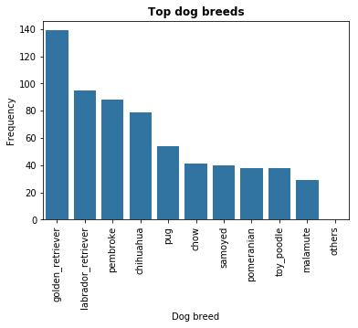

```python
breed_order = top10_breed.index

base_color = sns.color_palette()[0]
sns.countplot(data=master_df, x = 'p1', color=base_color, order=breed_order)
plt.xticks(rotation=90)

plt.title('Top dog breeds', fontweight = 'bold')
plt.xlabel('Dog breed')
plt.ylabel('Frequency')
```

Golden retriever tops the list of the dog breeds.

#### Insight #2: What is the association between retweet count and favorite count?

We calculate Pearson's correlation coefficient to determine the relationship between retweet count and favorite count.

```python
#Calculating the correlation coefficient

def corr_coeff(x,y):
    std_x = (x-x.mean())/x.std(ddof=0)
    std_y = (y-y.mean())/y.std(ddof=0)
    return (std_x*std_y).mean()

corr_coeff(master_df['retweet_count'], master_df['favorite_count'])
```

```
0.91173165335641015
```

```
Text(0,0.5,'Favorite Count')
```

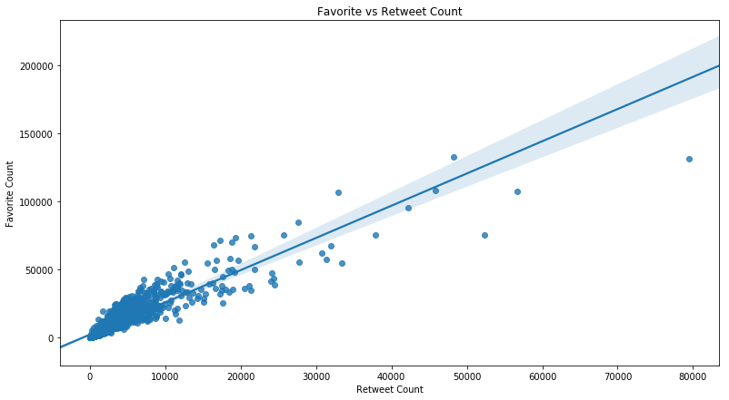

```python
plt.figure(figsize=(13,7))
sns.regplot(x=master_df['retweet_count'], y=master_df['favorite_count'])
plt.title('Favorite vs Retweet Count')
plt.xlabel('Retweet Count')
plt.ylabel('Favorite Count')
```

#### Insight #3: Which class of dog got the highest retweet and favorite count?

```python
dog_stage = master_df.groupby('stage').count().tweet_id
dog_stage
```

```
stage
None     2088
doggo      87
Name: tweet_id, dtype: int64
```

```python
res = master_df.groupby('stage').mean()[['retweet_count', 'favorite_count']]
res
```

| stage | retweet_count | favorite_count |
| --- | --- | --- |
| None | 2615.000958 | 8397.573755 |
| doggo | 6189.655172 | 17108.804598 |

### Conclusion

#### Limitation

- Getting the best way to deal with the rating whereby the rating numerator exceeds the limit of the given rating denominator

#### References

- https://stackoverflow.com/
- https://towardsdatascience.com/
- https://rpubs.com/keer707/WeRateDogs_tweet-Wrangle_Report
- https://classroom.udacity.com
- https://moonbooks.org/Articles/How-to-create-a-table-of-contents-in-a-jupyter-notebook-/